# Milestone Report

Dmitri Peredera

14 mars 2016

This document is an explanation of the major features of the data. Document is produced with *echo=FALSE*.

document should be concise and explain only the major features of the data you have identified and briefly summarize your plans for creating the prediction algorithm and Shiny app in a way that would be understandable to a non-data scientist manager. You should make use of tables and plots to illustrate important summaries of the data set. The motivation for this project is to:

## 1. Demonstrate that you’ve downloaded the data and have successfully loaded it in.

1. For the purpose of this document some helper functions were created.
   - *Helpers/DownloadFile()* - downloads and unzips file from web if file is missing.
   - All paths are declared in the *Helpers/filePaths.R* file and loaded int the Global.
   - *Helpers/CountFileLines()* - counts lines in file by reading them one by one.
   - *Helpers/GetLongestLine()* - reads lines one by one and finds the longest line.

```
## File exists in: C:/Users/Dmitri/Desktop/Documents/R Projects/Coursera/10 - DSS Capstone Project
```

The data consists of 4 directories, each corresponding different language with 3 files in each. Those directories are: de_DE, en_US, fi_FI, ru_RU.

Files are a collection of posts in different social medias:

- .blogs.txt - blog posts.
- .news.txt - news.
- .twitter.txt - tweets.

For the most, only the *en_US* locale is used in assignment.

## 2. Create a basic report of summary statistics about the data sets

The biggest file is the *blogs* file and it has the longest, measured in chars, document. The smallest and shortest file award goes to the *twitter* set, but it has mot documents of all sets.

| File | Size | Number of lines | Longest line |
| --- | --- | --- | --- |
| en_US.blogs.txt | 210.2 MB | 899,289 | 40,835 |
| en_US.news.txt | 205.8 MB | 77,260 | 5,760 |
| en_US.twitter.txt | 167.1 MB | 2,360,149 | 213 |

Given the known Twitter limit of max Characters per tweet equal to **140**, the twitter file will require some cleaning before processing.

## 3. Report any interesting findings that you amassed so far.

### Cleaning

As it was mentioned earlier, the twitter file contains some garbage. It has shown up, that most of that garbage is UTF codes in plaint test like:

`<f0><f0>`

Those codes are deleted at read using a simple regEx: `<(U\\+00..|f0)>`

### Reading the file

The file was too big to fit into the memory, so a small sample of first 25.000 lines was used. Given the total number of lines in files that was not a “fair” sample and there may be conveniences in the future.

Another problem is the *twitter* file because it has a large amount of small lines. So, instead of reading first N-rows, the files are read line by line until the given memory limit is reached by the *SampleFileByObjectSize* function.

```
## Processed samples files are in: C:/Users/Dmitri/Desktop/Documents/R Projects/Coursera/10 - DSS Capstone Project/sample
```

For the analysis part the *quanteda* package was used instead of suggested *tm* because of speed and lower memory usage.

There were some problems with the *quanteda*. Some documentation examples didn’t worked as expected.

- *dfm* didn’t lowered the words after *tokenize*’er.
- *toLower* couldn’t accepted the tokenized object as documentation says.

Most of the time, dfm objects would be constructed from texts or a corpus, without calling tokenize() as an intermediate step. Here, the punctuation and numbers must be removes, the the tokenizer is called. As well as *toLower* before tokinizer.

### Creating document-frequency matrix

The easiest way to examine document is to create a document-frequency matrix.

The produced DFM look like:

- Blogs: 25020, 48663
- News: 27720, 49022
- Twitter: 53400, 40956

Side by side, the wordcloud looks like (blogs, news, twitts):

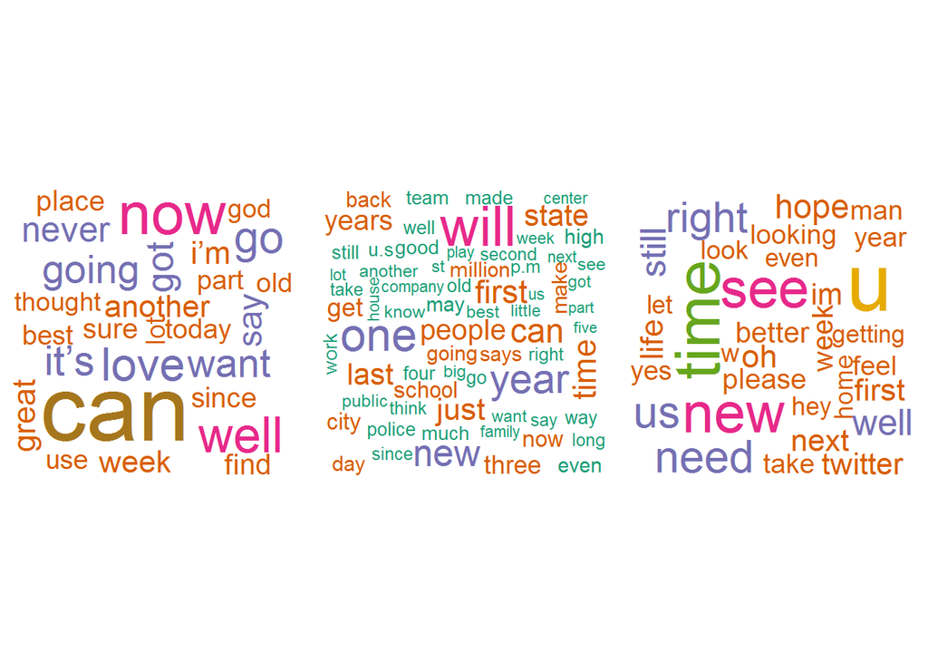

```r
# A vector of the form c(nr, nc)
par(mfrow=c(1,3))

plot(dfm.blogs, max.words = 80, colors = brewer.pal(8, "Dark2"), scale = c(8, .5))
plot(dfm.news, max.words = 80, colors = brewer.pal(8, "Dark2"), scale = c(8, .5))
plot(dfm.twitter, max.words = 80, colors = brewer.pal(8, "Dark2"), scale = c(8, .5))
```

Top features of corresponding set are presented in tables.

```r
topFeatures.blogs <- topfeatures(dfm.blogs, decreasing=T, n=20)
df_freq.blogs <- data.frame(keyName=names(topFeatures.blogs), value=topFeatures.blogs, row.names=NULL)
kable(df_freq.blogs, caption = "Top features of Blogs DFM.")
```

Top features of Blogs DFM.

| keyName | value |
| --- | --- |
| one | 3523 |
| will | 3093 |
| just | 2849 |
| like | 2806 |
| can | 2742 |
| time | 2616 |
| get | 1942 |
| know | 1774 |
| now | 1687 |
| people | 1577 |
| new | 1536 |
| also | 1498 |
| first | 1473 |
| us | 1441 |
| even | 1437 |
| much | 1416 |
| good | 1406 |
| back | 1401 |
| really | 1392 |
| make | 1390 |

```r
topFeatures.news <- topfeatures(dfm.news, decreasing=T, n=20)
df_freq.news <- data.frame(keyName=names(topFeatures.news), value=topFeatures.news, row.names=NULL)
kable(df_freq.news, caption = "Top features of News DFM.")
```

Top features of News DFM.

| keyName | value |
| --- | --- |
| said | 6865 |
| will | 3008 |
| one | 2420 |
| year | 2155 |
| new | 1868 |
| two | 1796 |
| also | 1631 |
| can | 1612 |
| time | 1599 |
| first | 1595 |
| just | 1506 |
| like | 1441 |
| last | 1404 |
| state | 1392 |
| people | 1343 |
| years | 1311 |
| get | 1175 |
| three | 1126 |
| now | 1028 |
| city | 1008 |

```r
topFeatures.twitter <- topfeatures(dfm.twitter, decreasing=T, n=20)
df_freq.twitter <- data.frame(keyName=names(topFeatures.twitter), value=topFeatures.twitter, row.names=NULL)
kable(df_freq.twitter, caption = "Top features of Twitter DFM.")
```

Top features of Twitter DFM.

| keyName | value |
| --- | --- |
| just | 3366 |
| like | 2832 |
| get | 2513 |
| love | 2418 |
| u | 2299 |
| good | 2261 |
| will | 2170 |
| can | 2134 |
| day | 2083 |
| thanks | 2073 |
| rt | 1991 |
| now | 1947 |
| one | 1946 |
| know | 1777 |
| great | 1720 |
| time | 1718 |
| go | 1674 |
| today | 1612 |
| lol | 1547 |
| new | 1524 |

As swoth, there are some differences in the sets.

## 4. Get feedback on your plans for creating a prediction algorithm and Shiny app.

There is some uncertainty in the plans. Mostly, I plan to continue examine n Grams of order 1-2-3-4 and predicting the results based on a simple fall-back strategy.

Try to find 4-grams and then move to lower numbers if nothing similar is found.

The most concerning part is smoothing and predicting the unknown words. Another concern is a very limited amount of time (must be on the fly) and resources.